# Introduction to (R) Programming

Marcin Kierczak

Sun, 11 Nov 2018

# R – what is it?

## Features of R

- a programming language,
- a programming platform (= environment + interpreter),
- a software project driven by the core team and the community.
- a very powerful tool for statistical computing,
- a very powerful computational tool in general,
- a catalyst between an idea and its realization.

## What R is not?

- a tool to replace a statistician,
- the very best programming language,
- the most elegant programming solution,
- the most efficient programming language.

## A brief history of R

- conceived c.a. 1992 by Robert Gentleman and [Ross Ihaka](https://en.wikipedia.org/wiki/Ross_Ihaka) (R&R) at the University of Auckland, NZ – a tool for teaching statistics,
- 1994 – initial version,
- 2000 – stable version.

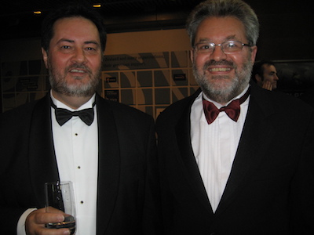

## The system of R packages – an overview

- developed by the community,
- cover several very diverse areas of science/life,
- uniformely structured and documented,
- organised in repositiries:
  - [CRAN](https://cran.r-project.org) - The Comprehensive R Archive Network,
  - [R-Forge](https://r-forge.r-project.org),
  - [Bioconductor](http://www.bioconductor.org),
  - [GitHub](https://github.com).

## R packages in the main repos

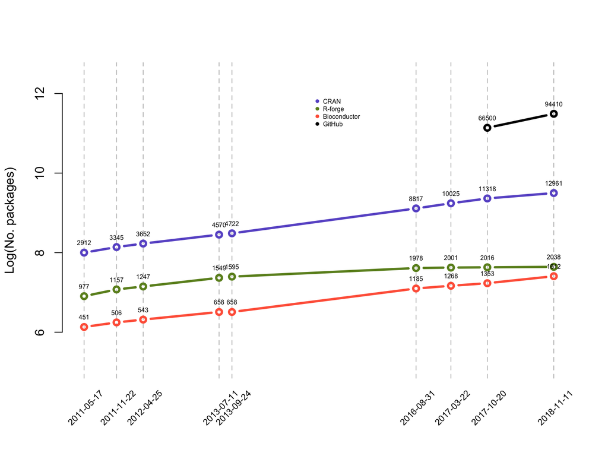

## Advantages of using R

- a very powerful ecosystem of packages,
- uniform, clear and clean system of documentation and help,
- good interconnectivity with compiled languages like Java or C,
- free and open source, GNU GPL and GNU GPL 2.0,
- easy to generate high quality graphics.

## Disadvantages of R

- steep learning curve,
- sometimes slow,
- difficulties due to a limited object-oriented programming capabilities, e.g. an agent-based simulation is a challenge,
- cannot order a pizza for you?

# What a programming language is?

## Definition of a programming language

> A programming language is a formal computer language or constructed language designed to communicate instructions to a machine, particularly a computer. Programming languages can be used to create programs to control the behavior of a machine or to express algorithms.[source: Wikipedia]

## What defines a programming language?

Think of a program as a flow of data from one function to another that does something to the data.

There are three main things that define a programming language:

- type system – what types of data can I process,
- syntax – the form defined by a language **grammar**,
- semantics – the meaning of statements.

# Syntax

## Syntax as form

- Syntax is the form, typically defined by the Chomsky II == [context-free](https://en.wikipedia.org/wiki/Context-free_grammar), **grammar** like:
  - 2 * 1 + 1
  - (+ (* 2 1) 1)

Programming language **Lisp** is defined by the following grammar (BNF or Bakus-Naur Form):

```
expression ::= atom | list
atom       ::= number | symbol
number     ::= [+-]?['0'-'9']+
symbol     ::= ['A'-'Z''a'-'z'].*
list       ::= '(' expression* ')'
```

# Semantics

## Semantics – give it a meaning

Semantics is the meaning, a gramatically correct sentence does not necessarily have a proper meaning:

- *“Colorful yellow train sleeps on a crazy wave.”* – has no generally accepted meaning.
- *“There is $500 on his empty bank acount.”* – cannot evaluate to true.

## Semantics – extra details

- *Static semantics* – in compiled languages, e.g. checking that every identifier is declared before the first use or that the conditionals have distinct predicates.
- *Dynamic semantics* – how the chunks of code are executed. For instance lazy vs. eager evaluation.

# The type system

## How to represent things?

- Untyped:
  - Assembler – everything is a byte.
- Typed:
  - 1 - integer
  - 1.0 - float
  - “1.0” - string
- Single type:
  - HTML – everything is a character.

## The type system – extra details

- Static vs. dynamic typing.
  - Static - type determined before execution, declared by the programmer (manifestly-typed) or checked by the compiler (type-inferrred) earlier:

    ```
    integer i   # Declaration
    i = 1       # Initialization
    ```

  - Dynamic - type determined when executing.

    ```
    i = 1
    ```

- Weak vs. strong types `1 + '1' =`
  - Weak - 2 or “11”
  - Strong - ERROR.

Types – ERROR checking!

# Programming paradigms

## Major types of programming languages

- **imperative** – a set of step-by-step instructions (R),
- **declarative** – a clearly defined goal.

## About programming paradigms

There many [programming paradigms](https://en.wikipedia.org/wiki/Programming_paradigm), e.g.:

- imperative:
  - literate (R, knitr, Sweavy, R Markdown),
  - procedural (R - functions),
  - …
- declarative:
  - functional (R, $\lambda$-abstraction),
  - …
- agent-oriented,
- structured:
  - object-oriented (R, S3 and S4 classes),
  - …
- …

# Interpreted vs. compiled languages

## Machine code

- Computers understand the **machine code** not programming languages!
- [Machine code](https://en.wikipedia.org/wiki/Machine_code) is what the processor (CPU) understands.
- Every computer language code has to be in some ways turned into the machine code.

## Interpreters and compilers

Two major approaches exist to turn code in a particular language to the machine code:

- **Interpretation** – on-the-fly translation of your code, theoretically line-by-line. This is done every time you run your program and the job is done by a software called an **interpreter**.
- **Compilation** – your program is translated and saved as a machine code and as such can be directly executed on the machine. The job is performed by a **compiler**.

## A more formal description of R

- Interpreted – it is every time translated by the interpreter.
- Dynamically typed – you do not declare types.
- Multi-paradigm:
  - array – works on multi-dimensional data structures, like vectors or matrices,
  - functional – treats computation as evaluation of math functions,
  - imperative – the programmer specifies how to solve the problem,
  - object-oriented – allows working with objects: data + things you can do to the data,
  - procedural – structure is organised in procedures and procedure calls, e.g. functions and
  - reflective – the code can modify itself in runtime.

## So how to program?

*Divide et impera* – Divide and rule.

**Top-down approach:** define the big problem and split it into smaller ones. Assume you have solution to the small problems and continue – push the responsibility down. Wishful thinking!

```
You've got a csv file that contains data about people:
year of birth, favorite music genre and the name of
a pet if the person has one and salary. Your task is
to read the data and, for people born in particular
decades (..., 50-ties, 60-ties, ...), compute the
mean and the variance salary and find the most
frequent pet name.
```

## Problem decomposition 1

This task can be decomposed into:

- read data from csv file,
- split the data into age classes based on the decade of birth,
- compute the mean and the variance salary per class,
- find the most frequent pet name per class.

## Problem decomposition 2

To compute an the mean you have to: *sum all values*, *divide the sum by the number of values* – simple enough, we can program it right away.

To compute the variance you need to first refresh the formula:
$$Var(X) = \frac{1}{n} \Sigma_{i=1}^{n} (x_{i} - \bar{x})^2$$

Thus, you realise that you need to compute the mean, but you know how to do this from the previous point. So, instead of coding computation of the mean twice, make a function that you can reuse! Lazines is the major driving force of a programmer!

Let’s put it down!

## Pseudocode 1

$$Var(X) = \frac{1}{n} \Sigma_{i=1}^{n} (x_{i} - \bar{x})^2$$

**Task:** create the computeMean procedure that computes the mean for a sequence of numbers

**Input:** a sequence of numbers, e.g.: {1, 4, 5.7, 42357.533, 42}. Wait, isn’t it a *vector*?

**Output:** the computed mean, a single number, that is what we want our procedure to return.

```
function computeMean(aVector) {
    sum = sum all numbers in aVector
    count = count how many numbers are in aVector
    theMean is: sum / count
    return theMean
}
```

## Summary

So far, we have learnt about:

- what R is and what it is not,
- history of R,
- the system of packages,
- advantages and disadvantages of the language,
- definition of a programing language,
- elements of a programing language (types, syntax and semantics),
- programing paradigms,
- wishful thinking,
- problem decomposition,
- pseudocode.

Quite a bit, right?